# Seamus_Gallivan_R_Final_Exam

Seamus Gallivan

17 December 2019

#Seamus Gallivan# #12/12/19# #SPHU 4160 Final Exam#

#the tidyverse, dplyr, stringr, car and modeest package will be used for this R markdown file#

```r
library(tidyverse)
library(dplyr)
library(stringr)
library(modeest)
library(car)
```

# Compile date and session info

```r
# print and get runtime ----
date()
```

```
[1] "Tue Dec 17 23:36:58 2019"
```

#read in the nola_crime_2018 dataset#

```r
nola_crime <- read_csv(file="nola_crime_2018.csv")
```

#Question 1 and 2#

```r
str(nola_crime)
```

```
Classes ‘spec_tbl_df’, ‘tbl_df’, ‘tbl’ and 'data.frame':    9970 obs. of  24 variables:
 $ Item_Number        : chr  "L-12475-18" "F-20790-18" "L-20684-18" "G-22793-18" ...
 $ District           : num  8 6 7 3 1 3 5 7 5 7 ...
 $ Location           : chr  "X Canal St" "24XX Erato St" "45XX Lafon Dr" "3XX Mouton St" ...
 $ Disposition        : chr  "OPEN" "OPEN" "OPEN" "OPEN" ...
 $ Signal_Type        : chr  "67F" "103D" "103D" "62C" ...
 $ Signal_Description : chr  "THEFT BY FRAUD" "DISTURBANCE (DOMESTIC)" "DISTURBANCE (DOMESTIC)" "SIMPLE BURGLARY (VEHICLE)" ...
 $ Occurred_Date_Time : chr  "12/10/2018 6:00" "6/17/2018 23:18" "12/16/2018 13:30" "7/18/2018 19:15" ...
 $ Charge_Code        : chr  "14 70.4" NA NA "14 62" ...
 $ Charge_Description : chr  "ACCESS DEVICE FRAUD" NA NA "SIMPLE BURGLARY" ...
 $ Offender_Race      : chr  NA NA NA "BLACK" ...
 $ Offender_Gender    : chr  NA NA NA "MALE" ...
 $ Offender_Age       : num  NA NA NA 16 29 NA NA 45 51 NA ...
 $ Offender_Number    : num  1 NA NA 2 1 NA 1 1 1 2 ...
 $ Person_Type        : chr  "VICTIM" "INTERVIEW" "REPORTING PERSON" "VICTIM" ...
 $ Victim_Race        : chr  "WHITE" "BLACK" "BLACK" "WHITE" ...
 $ Victim_Gender      : chr  "MALE" "FEMALE" "FEMALE" "MALE" ...
 $ Victim_Age         : num  62 33 35 35 NA 29 38 39 NA NA ...
 $ Victim_Number      : num  1 2 1 1 1 1 1 2 1 1 ...
 $ Victim_Fatal_Status: chr  "Non-fatal" "Non-fatal" "Non-fatal" "Non-fatal" ...
 $ Hate_Crime         : logi  NA NA NA NA NA NA ...
 $ Report_Type        : chr  "Incident Report" "Incident Report" "Incident Report" "Supplemental Report" ...
 $ address            : chr  "X Canal St., New Orleans, LA" "2400 Erato St., New Orleans, LA" "4500 Lafon Dr., New Orleans, LA" "300 Mouton St., New Orleans, LA" ...
 $ GNOCDC_LAB         : chr  "TULANE - GRAVIER" "CENTRAL CITY" "PLUM ORCHARD" "LAKEVIEW" ...
 $ pop                : num  17445 35385 14671 16938 23878 ...
 - attr(*, "spec")=
  .. cols(
  ..   Item_Number = col_character(),
  ..   District = col_double(),
  ..   Location = col_character(),
  ..   Disposition = col_character(),
  ..   Signal_Type = col_character(),
  ..   Signal_Description = col_character(),
  ..   Occurred_Date_Time = col_character(),
  ..   Charge_Code = col_character(),
  ..   Charge_Description = col_character(),
  ..   Offender_Race = col_character(),
  ..   Offender_Gender = col_character(),
  ..   Offender_Age = col_double(),
  ..   Offender_Number = col_double(),
  ..   Person_Type = col_character(),
  ..   Victim_Race = col_character(),
  ..   Victim_Gender = col_character(),
  ..   Victim_Age = col_double(),
  ..   Victim_Number = col_double(),
  ..   Victim_Fatal_Status = col_character(),
  ..   Hate_Crime = col_logical(),
  ..   Report_Type = col_character(),
  ..   address = col_character(),
  ..   GNOCDC_LAB = col_character(),
  ..   pop = col_double()
  .. )
```

#Observations = 9970, Variables = 24#

#Question 3#

```r
length(unique(nola_crime$Item_Number))
```

```
[1] 9384
```

#9384 unique item numbers#

#Question 4#

```r
nola_crime %>%
  select(GNOCDC_LAB, Signal_Description, Item_Number) %>%
  filter(str_detect(Signal_Description, "AGG")) %>%
filter(GNOCDC_LAB=="IRISH CHANNEL")
```

| GNOCDC_LAB | Signal_Description | Item_Number |
| --- | --- | --- |
| IRISH CHANNEL | AGGRAVATED ASSAULT | B-15298-18 |

#1 Aggravated Crime in The Irish Channel Neighorhood#

#Question 5#

```r
nola_crime <- nola_crime %>%
  group_by(GNOCDC_LAB) %>%
  mutate(unique_item_numbers = n_distinct(Item_Number))
nola_crime %>%
  arrange(desc(unique_item_numbers)) %>%
  select(GNOCDC_LAB, unique_item_numbers) %>%
  distinct(GNOCDC_LAB, .keep_all = TRUE)
```

| GNOCDC_LAB | unique_item_numbers |
| --- | --- |
| FRENCH QUARTER | 670 |
| LITTLE WOODS | 595 |
| CENTRAL BUSINESS DISTRICT | 551 |
| CENTRAL CITY | 540 |
| SEVENTH WARD | 401 |
| NA | 393 |
| MID-CITY | 344 |
| ST. CLAUDE | 294 |
| ST. ROCH | 291 |
| BEHRMAN | 232 |

[output cut: 63 more lines]

#Two largest number of crime reports = FRENCH QUARTER & LITTLE WOODS#

#Question 6#

```r
nola_crime <- nola_crime %>% mutate(
  crime_rate = (unique_item_numbers *1000/ pop)
)
#multiply numerator by 1000
nola_crime %>%
  select(pop,unique_item_numbers,crime_rate,GNOCDC_LAB) %>%
  distinct(GNOCDC_LAB, .keep_all = TRUE)
```

| pop | unique_item_numbers | crime_rate | GNOCDC_LAB |
| --- | --- | --- | --- |
| 17445 | 205 | 11.7512181 | TULANE - GRAVIER |
| 35385 | 540 | 15.2607037 | CENTRAL CITY |
| 14671 | 90 | 6.1345512 | PLUM ORCHARD |
| 16938 | 53 | 3.1290589 | LAKEVIEW |
| 23878 | 401 | 16.7937013 | SEVENTH WARD |
| 32067 | 291 | 9.0747497 | ST. ROCH |
| 18616 | 294 | 15.7928664 | ST. CLAUDE |
| 12942 | 105 | 8.1131201 | HOLY CROSS |
| 15172 | 670 | 44.1602953 | FRENCH QUARTER |
| 9228 | 161 | 17.4469007 | LOWER NINTH WARD |

[output cut: 63 more lines]

```r
nola_crime %>%
  group_by(GNOCDC_LAB) %>%
  select(GNOCDC_LAB,crime_rate) %>%
  distinct(GNOCDC_LAB, crime_rate)
```

| GNOCDC_LAB | crime_rate |
| --- | --- |
| TULANE - GRAVIER | 11.7512181 |
| CENTRAL CITY | 15.2607037 |
| PLUM ORCHARD | 6.1345512 |
| LAKEVIEW | 3.1290589 |
| SEVENTH WARD | 16.7937013 |
| ST. ROCH | 9.0747497 |
| ST. CLAUDE | 15.7928664 |
| HOLY CROSS | 8.1131201 |
| FRENCH QUARTER | 44.1602953 |
| LOWER NINTH WARD | 17.4469007 |

[output cut: 63 more lines]

```r
NA
```

#Question 7#

```r
nola_crime %>%
  select(GNOCDC_LAB, pop) %>%
  arrange(desc(pop))
```

| GNOCDC_LAB | pop |
| --- | --- |
| LITTLE WOODS | 44947 |
| LITTLE WOODS | 44947 |
| LITTLE WOODS | 44947 |
| LITTLE WOODS | 44947 |
| LITTLE WOODS | 44947 |
| LITTLE WOODS | 44947 |
| LITTLE WOODS | 44947 |
| LITTLE WOODS | 44947 |
| LITTLE WOODS | 44947 |
| LITTLE WOODS | 44947 |

[output cut: 990 more lines]

#Largest neighborhood by population = LITTLE WOODS, population = 44947#

#Question 8#

```r
nola_crime %>%
  select(pop, unique_item_numbers, GNOCDC_LAB, crime_rate) %>%
  arrange(crime_rate)
```

| pop | unique_item_numbers | GNOCDC_LAB | crime_rate |
| --- | --- | --- | --- |
| 13989 | 10 | LAKEWOOD | 0.7148474 |
| 13989 | 10 | LAKEWOOD | 0.7148474 |
| 13989 | 10 | LAKEWOOD | 0.7148474 |
| 13989 | 10 | LAKEWOOD | 0.7148474 |
| 13989 | 10 | LAKEWOOD | 0.7148474 |
| 13989 | 10 | LAKEWOOD | 0.7148474 |
| 13989 | 10 | LAKEWOOD | 0.7148474 |
| 13989 | 10 | LAKEWOOD | 0.7148474 |
| 13989 | 10 | LAKEWOOD | 0.7148474 |
| 13989 | 10 | LAKEWOOD | 0.7148474 |

[output cut: 990 more lines]

#Lowest crime rate = LAKEWOOD, population = 13989, unique crimes = 10#

#Question 9#

```r
nola_crime %>%
  filter(GNOCDC_LAB=="LAKEWOOD")
```

| Item_Number | District | Location | Disposition | Signal_Type | Signal_Description | Occurred_Date_Time | Charge_Code | Charge_Description | Offender_Race | Offender_Gender | Offender_Age | Offender_Number | Person_Type | Victim_Race | Victim_Gender | Victim_Age | Victim_Number | Victim_Fatal_Status | Hate_Crime | Report_Type | address | GNOCDC_LAB | pop | unique_item_numbers | crime_rate |
| --- | --- | --- | --- | --- | --- | --- | --- | --- | --- | --- | --- | --- | --- | --- | --- | --- | --- | --- | --- | --- | --- | --- | --- | --- | --- |
| G-38396-18 | 3 | 55XX Dayna Ct | OPEN | 67 | THEFT | 7/31/2018 11:37 | 14 67 | THEFT | UNKNOWN | NA | NA | 1 | VICTIM | WHITE | FEMALE | 45 | 1 | Non-fatal | NA | Incident Report | 5500 Dayna Ct., New Orleans, LA | LAKEWOOD | 13989 | 10 | 0.7148474 |
| A-02548-18 | 3 | 1XX Bellaire Dr | OPEN | 29 | DEATH | 1/3/2018 0:10 | NA | NA | NA | NA | NA | NA | WITNESS | BLACK | FEMALE | 69 | 3 | Non-fatal | NA | Incident Report | 100 Bellaire Dr., New Orleans, LA | LAKEWOOD | 13989 | 10 | 0.7148474 |
| D-35558-18 | 3 | 50XX Pontchartrain Bd | OPEN | 29U | UNCLASSIFIED DEATH | 4/29/2018 22:15 | NA | NA | NA | NA | NA | NA | VICTIM | WHITE | MALE | 40 | 1 | Fatal | NA | Incident Report | 5000 Pontchartrain Bd., New Orleans, LA | LAKEWOOD | 13989 | 10 | 0.7148474 |
| K-18355-18 | 3 | 50XX Pontchartrain Bd | OPEN | 62B | SIMPLE BURGLARY (BUSINESS) | 11/14/2018 4:19 | NA | NA | NA | NA | NA | 1 | REPORTING PERSON | WHITE | MALE | NA | 1 | Non-fatal | NA | Incident Report | 5000 Pontchartrain Bd., New Orleans, LA | LAKEWOOD | 13989 | 10 | 0.7148474 |
| J-28837-18 | 3 | 58XX Bellaire Dr | OPEN | 103 | DISTURBANCE | 10/22/2018 14:00 | NA | NA | WHITE | MALE | 52 | 1 | VICTIM | WHITE | MALE | 52 | 2 | Non-fatal | NA | Incident Report | 5800 Bellaire Dr., New Orleans, LA | LAKEWOOD | 13989 | 10 | 0.7148474 |
| B-02700-18 | 3 | 56XX Cherlyn Dr | CLOSED | 63 | TRESPASSING | 2/3/2018 6:28 | NA | NA | BLACK | MALE | 58 | 1 | WITNESS | BLACK | MALE | 56 | 2 | Non-fatal | NA | Incident Report | 5600 Cherlyn Dr., New Orleans, LA | LAKEWOOD | 13989 | 10 | 0.7148474 |
| J-28837-18 | 3 | 58XX Bellaire Dr | OPEN | 103 | DISTURBANCE | 10/22/2018 14:00 | NA | NA | WHITE | MALE | 52 | 1 | WITNESS | WHITE | MALE | 19 | 4 | Non-fatal | NA | Incident Report | 5800 Bellaire Dr., New Orleans, LA | LAKEWOOD | 13989 | 10 | 0.7148474 |
| G-20874-18 | 3 | 91XX Peach St | OPEN | 62C | SIMPLE BURGLARY (VEHICLE) | 7/17/2018 13:48 | 14 62 | SIMPLE BURGLARY | UNKNOWN | NA | NA | 1 | VICTIM | BLACK | MALE | 70 | 1 | Non-fatal | NA | Incident Report | 9100 Peach St., New Orleans, LA | LAKEWOOD | 13989 | 10 | 0.7148474 |
| H-06960-18 | 3 | 51XX Pontchartrain Bd | CLOSED | 35 | SIMPLE BATTERY | 8/6/2018 13:30 | 54 96 | BATTERY | WHITE | MALE | 51 | 1 | VICTIM | WHITE | MALE | 60 | 1 | Non-fatal | NA | Supplemental Report | 5100 Pontchartrain Bd., New Orleans, LA | LAKEWOOD | 13989 | 10 | 0.7148474 |
| F-17929-18 | 3 | 40XX Hamilton St | OPEN | 103D | DISTURBANCE (DOMESTIC) | 6/15/2018 12:30 | NA | NA | NA | NA | NA | NA | INTERVIEW | BLACK | FEMALE | 41 | 2 | Non-fatal | NA | Incident Report | 4000 Hamilton St., New Orleans, LA | LAKEWOOD | 13989 | 10 | 0.7148474 |

[output cut: 1 more lines]

```r
nola_crime <- nola_crime %>%
  mutate(
    rate_ratio = crime_rate / 0.7148474
  )
nola_crime %>%
  select(GNOCDC_LAB, rate_ratio) %>%
  distinct(GNOCDC_LAB, rate_ratio)
```

| GNOCDC_LAB | rate_ratio |
| --- | --- |
| TULANE - GRAVIER | 16.438779 |
| CENTRAL CITY | 21.348198 |
| PLUM ORCHARD | 8.581623 |
| LAKEVIEW | 4.377240 |
| SEVENTH WARD | 23.492708 |
| ST. ROCH | 12.694667 |
| ST. CLAUDE | 22.092640 |
| HOLY CROSS | 11.349443 |
| FRENCH QUARTER | 61.775835 |
| LOWER NINTH WARD | 24.406469 |

[output cut: 63 more lines]

```r
#just need to adjust crime rate calculated previously
```

#Question 10#

```r
nola_crime1 <- nola_crime %>%
  group_by(GNOCDC_LAB) %>%
  filter(str_detect(Signal_Description, "AGG")) %>%
  mutate(
    unique_agg_crimes = n_distinct(Item_Number)
  ) %>%
  mutate(
    unique_agg_crime_rate = (unique_agg_crimes / pop) * 1000
  )
nola_crime1 %>%
  group_by(GNOCDC_LAB) %>%
  select(GNOCDC_LAB, unique_agg_crime_rate) %>%
  filter(str_detect(GNOCDC_LAB, "FRENCH QUARTER"))
```

| GNOCDC_LAB | unique_agg_crime_rate |
| --- | --- |
| FRENCH QUARTER | 0.9886633 |
| FRENCH QUARTER | 0.9886633 |
| FRENCH QUARTER | 0.9886633 |
| FRENCH QUARTER | 0.9886633 |
| FRENCH QUARTER | 0.9886633 |
| FRENCH QUARTER | 0.9886633 |
| FRENCH QUARTER | 0.9886633 |
| FRENCH QUARTER | 0.9886633 |
| FRENCH QUARTER | 0.9886633 |
| FRENCH QUARTER | 0.9886633 |

[output cut: 11 more lines]

```r
nola_crime1 <- nola_crime1 %>%
  group_by(GNOCDC_LAB) %>%
  mutate(
    agg_rate_ratio = unique_agg_crime_rate / 0.9886633
  )
nola_crime1 %>%
  group_by(GNOCDC_LAB)%>%
  select(agg_rate_ratio, GNOCDC_LAB) %>%
  distinct(agg_rate_ratio, GNOCDC_LAB)
```

| agg_rate_ratio | GNOCDC_LAB |
| --- | --- |
| 0.75837596 | PLUM ORCHARD |
| NA | NA |
| 0.27698136 | MILNEBURG |
| 0.18322842 | GERT TOWN |
| 0.32891087 | BROADMOOR |
| 0.46853191 | MILAN |
| 0.22103730 | U.S. NAVAL BASE |
| 0.23775720 | LEONIDAS |
| 0.83263105 | LITTLE WOODS |
| 0.44378500 | WEST LAKE FOREST |

[output cut: 47 more lines]

#Question 11#

```r
mfv(nola_crime$Signal_Description)
```

```
[1] "DISTURBANCE (DOMESTIC)"
```

```r
mfv(nola_crime$Charge_Description, na_rm = TRUE)
```

```
[1] "THEFT"
```

#most common cause for police report = “DISTURBANCE (DOMESTIC)”# #most common charge that is filed = “THEFT”

#Question 12#

```r
nola_crime1 <- nola_crime %>%
  filter(Signal_Description == "DISTURBANCE (DOMESTIC)") %>%
  mutate(
    domestic_disturbances = n_distinct(Item_Number)
  )
nola_crime1 <- nola_crime1 %>%
  mutate(
    dom_dist_rate = (domestic_disturbances / pop) * 1000
  )
nola_crime1 %>%
  select(GNOCDC_LAB, dom_dist_rate) %>%
  distinct(GNOCDC_LAB, dom_dist_rate)
```

| GNOCDC_LAB | dom_dist_rate |
| --- | --- |
| CENTRAL CITY | 2.06302105 |
| PLUM ORCHARD | 1.63588031 |
| ST. ROCH | 1.96463654 |
| LITTLE WOODS | 3.22602176 |
| VILLAGE DE LEST | 0.86460994 |
| HOLLYGROVE | 3.83860786 |
| TALL TIMBERS - BRECHTEL | 1.78399502 |
| LOWER GARDEN DISTRICT | 0.96215523 |
| HOLY CROSS | 1.93169526 |
| U.S. NAVAL BASE | 1.14729021 |

[output cut: 62 more lines]

```r
#decimal point issue
```

#Question 13#

```r
nola_crime2 <- nola_crime %>%
  group_by(GNOCDC_LAB,crime_rate) %>%
  select(GNOCDC_LAB,crime_rate,Victim_Age) %>%
  summarize(m = mean(Victim_Age, na.rm = TRUE))
 #encountered an error in argument "by"

nola_crime2
```

| GNOCDC_LAB | crime_rate | m |
| --- | --- | --- |
| ALGIERS POINT | 2.0236613 | 42.12000 |
| AUDUBON | 2.7143836 | 39.07246 |
| B. W. COOPER | 3.3243831 | 37.63636 |
| BAYOU ST. JOHN | 2.3253411 | 42.10526 |
| BEHRMAN | 9.0759721 | 38.13812 |
| BLACK PEARL | 1.6745319 | 38.12500 |
| BROADMOOR | 5.5931322 | 39.84416 |
| BYWATER | 5.7573953 | 42.40196 |
| CENTRAL BUSINESS DISTRICT | 29.3647410 | 39.18310 |
| CENTRAL CITY | 15.2607037 | 39.72040 |

[output cut: 63 more lines]

```r
  linearreg <- lm(m ~ crime_rate, data = nola_crime2)
  print(linearreg)
```

```
Call:
lm(formula = m ~ crime_rate, data = nola_crime2)

Coefficients:
(Intercept)   crime_rate
   40.24515     -0.07622
```

```r
  summary(linearreg)
```

```
Call:
lm(formula = m ~ crime_rate, data = nola_crime2)

Residuals:
     Min       1Q   Median       3Q      Max
-10.1955  -2.0205  -0.0859   1.7191  15.3431

Coefficients:
            Estimate Std. Error t value Pr(>|t|)
(Intercept) 40.24515    0.62765  64.121   <2e-16 ***
crime_rate  -0.07622    0.06732  -1.132    0.261
---
Signif. codes:  0 ‘***’ 0.001 ‘**’ 0.01 ‘*’ 0.05 ‘.’ 0.1 ‘ ’ 1

Residual standard error: 3.759 on 70 degrees of freedom
  (1 observation deleted due to missingness)
Multiple R-squared:  0.01799,   Adjusted R-squared:  0.003957
F-statistic: 1.282 on 1 and 70 DF,  p-value: 0.2614
```

```r
  #did run correctly, nola_crime2 was not found
```

#Question 14#

```r
nola_crime %>%
  select(GNOCDC_LAB, crime_rate) %>%
  arrange(crime_rate)
```

| GNOCDC_LAB | crime_rate |
| --- | --- |
| LAKEWOOD | 0.7148474 |
| LAKEWOOD | 0.7148474 |
| LAKEWOOD | 0.7148474 |
| LAKEWOOD | 0.7148474 |
| LAKEWOOD | 0.7148474 |
| LAKEWOOD | 0.7148474 |
| LAKEWOOD | 0.7148474 |
| LAKEWOOD | 0.7148474 |
| LAKEWOOD | 0.7148474 |
| LAKEWOOD | 0.7148474 |

[output cut: 990 more lines]

#Since LAKEWOOD had the lowest crime rate, it also had the lowest police reponsiveness. LAKEWOOD had the least value of least amonunt of Signals per population#

#Question 15#

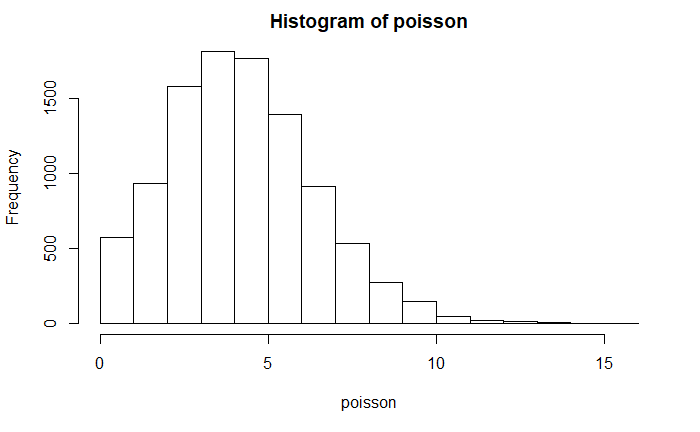

```r
poisson <- rpois(10000, 4.7)
hist(poisson)
```

#Question 16#

```r
sp.l <- split(iris,iris$Species)
res <- list()
for(n in names(sp.l)){
   dat <- sp.l[[n]]
   res[[n]] <- data.frame(species=n,
                          mean.sepal.length=mean(dat$Sepal.Length))

}
print(res)
```

```
$setosa
  species mean.sepal.length
1  setosa             5.006

$versicolor
     species mean.sepal.length
1 versicolor             5.936

$virginica
    species mean.sepal.length
1 virginica             6.588
```

#Question 17#

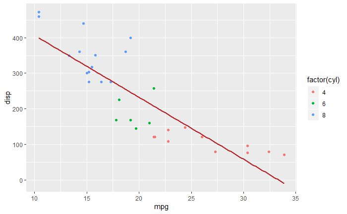

```r
mtcarsplot <- ggplot(mtcars, aes(x = mpg, y = disp)) +
    geom_point(aes(color = factor(cyl))) +
stat_smooth(method = "lm",
        col = "#C42126",
        se = FALSE,
        size = 1)
linearmodel <- lm(disp ~ mpg, data = mtcars)
mtcarsplot
```

```r
#change axes since question asks for mpg vs. disp so mpg on the y-axis and disp on the x-axis
summary(linearmodel)
```

```
Call:
lm(formula = disp ~ mpg, data = mtcars)

Residuals:
    Min      1Q  Median      3Q     Max
-103.05  -45.74   -8.17   46.65  153.75

Coefficients:
            Estimate Std. Error t value Pr(>|t|)
(Intercept)  580.884     41.740  13.917 1.26e-14 ***
mpg          -17.429      1.993  -8.747 9.38e-10 ***
---
Signif. codes:  0 ‘***’ 0.001 ‘**’ 0.01 ‘*’ 0.05 ‘.’ 0.1 ‘ ’ 1

Residual standard error: 66.86 on 30 degrees of freedom
Multiple R-squared:  0.7183,    Adjusted R-squared:  0.709
F-statistic: 76.51 on 1 and 30 DF,  p-value: 9.38e-10
```

#Question 18#

```r
z_score_function <- function(x) {
  z_score <- (x-mean(x))/sd(x)
  return(z_score)
}
vector_values=c(-4.89, -1.93, -1.11, 3.94, 0.46, -3.85, -0.20, 6.04,
9.36, 7.26, 4.88, 13.45, -2.93, 6.39, -16.22, -3.24, 6.86, 11.87, 1.81, -2.54)
z_score_function(vector_values)
```

```
 [1] -0.968299066 -0.537976232 -0.418765177  0.315400469 -0.190519620 -0.817104557
 [7] -0.286469981  0.620697074  1.103356469  0.798059864  0.452057045  1.697957953
[13] -0.683355568  0.671579842 -2.615446941 -0.728423162  0.739908130  1.468258602
[19]  0.005742484 -0.626657627
```

#EXTRA CREDIT# #Question 20#

```
col is not of length 1 or nrow(x): colors will be recycled; use pal to specify a color palette
```

[figure not shown]

```r
library(raster)
library(sf)
library(rgeos)
library(maptools)
nola_map <- read_sf(dsn = "./Neighborhood_Statistical_Areas", layer = "Neighborhood_Statistical_Areas")

m <- merge(nola_crime, nola_map, by='GNOCDC_LAB')
p <- colorRampPalette(c("white", "red"))(128)
palette(p)
rate <- m$rate_ratio
cols <- (rate - min(rate))/diff(range(rate))*127+1
plot(nola_map, col=cols)
```